# Argus Media - Oil Dataset Project

### LINEAR OR NON-LINEAR RELATION TO OILPRICE PLOT

Now let’s have a quick view if the variables has a linear or non-linear relation to OILPRICE

```r
p1 <- ggplot(df, aes(SPX_log, OILPRICE)) + geom_point()
p2 <- ggplot(df, aes(DX1_log, OILPRICE)) +  geom_point()
p3 <- ggplot(df, aes(BDIY_log, OILPRICE)) +  geom_point()
p4 <- ggplot(df, aes(GC1_log, OILPRICE)) +  geom_point()
p5 <- ggplot(df, aes(HO1_log, OILPRICE)) +  geom_point()
p6 <- ggplot(df, aes(FTSE_log, OILPRICE)) +  geom_point()
p7 <- ggplot(df, aes(USCI_log, OILPRICE)) +  geom_point()
p8 <- ggplot(df, aes(GNR_log, OILPRICE)) +  geom_point()
p9 <- ggplot(df, aes(SHCOMP_log, OILPRICE)) +  geom_point()
```

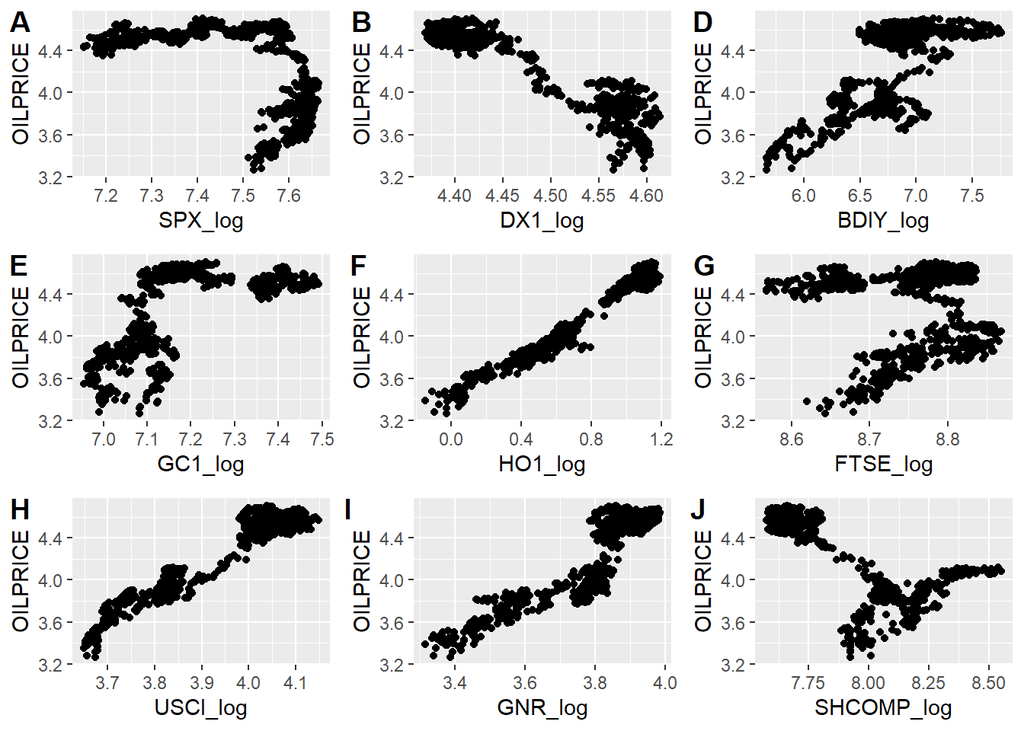

```r
plot_grid(p1,
          p2,
          p3,
          p4,
          p5,
          p6,
          p7,
          p8,
          p9,
        labels = c('A', 'B', 'D', 'E', 'F', 'G', 'H', 'I', 'J'))# Zoom it (better visualization)
```

We have a clear linear relation between the target variable and the predictor variables ‘DX1_log’, ‘HO1_log’, ‘USCI_log’ and ‘GNR_log’. The other varuables dont have such explicit linear relation but can be interpreted as much.

The plots views give us brief information about X’s relation with the Y variable (Oilprice). Some of them we can visualize if there is a positive or negative correlation. So what We can expect from the models coefficients signal:

SPX - Undefined Correlation DX1 - Negative Correlation BDIY - Positive Correlation GC1 - Undefined Correlation HO1 - Positive Correlation FTSE - Undefined Correlation USCI - Positive Correlation GNR - Positive Correlation SHCOMP - Undefined Correlation

### VARIABLES DISTRIBUTIONS

Having a overview of the variable distributions

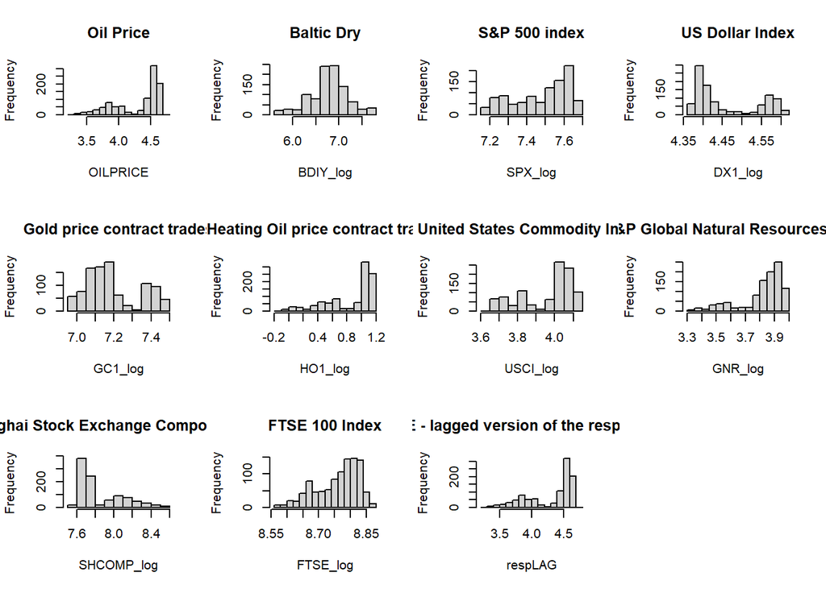

```r
attach(df)
par(mfrow=c(3,4))
hist(OILPRICE, main="Oil Price")
hist(BDIY_log, main="Baltic Dry")
hist(SPX_log, main="S&P 500 index")
hist(DX1_log, main="US Dollar Index")
hist(GC1_log, main="Gold price contract trades")
hist(HO1_log, main="Heating Oil price contract traded")
hist(USCI_log, main="United States Commodity Index")
hist(GNR_log, main="S&P Global Natural Resources Index")
hist(SHCOMP_log,main="Shanghai Stock Exchange Composite Index")
hist(FTSE_log, main="FTSE 100 Index")
hist(respLAG, main="OILPRICE - lagged version of the response variable")
```

### VARIABLES CORRELATION

As We can see, most of the variables don’t follow a normal distribution, so if We want to analyse a correlation metric, it will need a non parametric Correlation-test (Spearmen). Now We can confirm the previous plots and the real variables correlation.

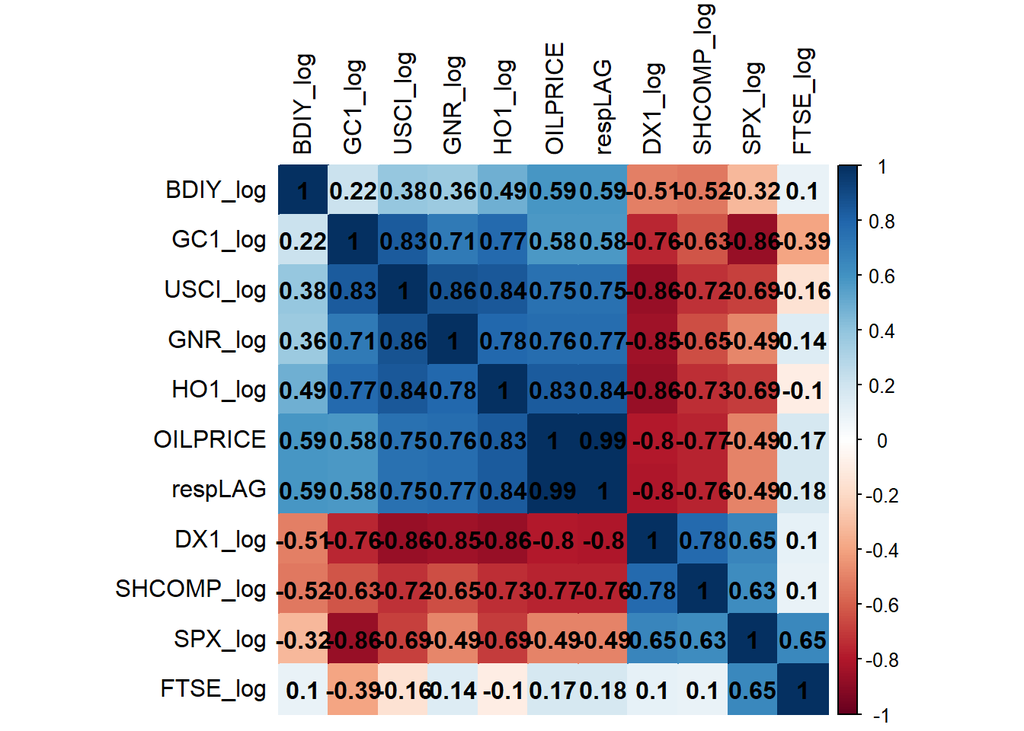

```r
corr_mat=cor(df,method="s")
corrplot(corr_mat, method = "color",
         order = "hclust",
         addCoef.col = "black",
         tl.col = "black")
```

Let’s check if these correlations are significant

```r
Matrix1 <- rcorr(as.matrix(df), type = "spearman")
print(Matrix1$P)# P-value of the correlations
```

```
##                OILPRICE     BDIY_log SPX_log     DX1_log      GC1_log
## OILPRICE             NA 0.000000e+00       0 0.000000000 0.000000e+00
## BDIY_log   0.000000e+00           NA       0 0.000000000 3.120171e-12
## SPX_log    0.000000e+00 0.000000e+00      NA 0.000000000 0.000000e+00
## DX1_log    0.000000e+00 0.000000e+00       0          NA 0.000000e+00
## GC1_log    0.000000e+00 3.120171e-12       0 0.000000000           NA
## HO1_log    0.000000e+00 0.000000e+00       0 0.000000000 0.000000e+00
## USCI_log   0.000000e+00 0.000000e+00       0 0.000000000 0.000000e+00
## GNR_log    0.000000e+00 0.000000e+00       0 0.000000000 0.000000e+00
## SHCOMP_log 0.000000e+00 0.000000e+00       0 0.000000000 0.000000e+00
## FTSE_log   3.288032e-08 2.359658e-03       0 0.001514743 0.000000e+00
## respLAG    0.000000e+00 0.000000e+00       0 0.000000000 0.000000e+00
##                HO1_log     USCI_log      GNR_log  SHCOMP_log     FTSE_log
## OILPRICE   0.000000000 0.000000e+00 0.000000e+00 0.000000000 3.288032e-08
## BDIY_log   0.000000000 0.000000e+00 0.000000e+00 0.000000000 2.359658e-03
## SPX_log    0.000000000 0.000000e+00 0.000000e+00 0.000000000 0.000000e+00
## DX1_log    0.000000000 0.000000e+00 0.000000e+00 0.000000000 1.514743e-03
## GC1_log    0.000000000 0.000000e+00 0.000000e+00 0.000000000 0.000000e+00
## HO1_log             NA 0.000000e+00 0.000000e+00 0.000000000 2.122789e-03
## USCI_log   0.000000000           NA 0.000000e+00 0.000000000 4.528966e-07
## GNR_log    0.000000000 0.000000e+00           NA 0.000000000 7.927264e-06
## SHCOMP_log 0.000000000 0.000000e+00 0.000000e+00          NA 2.344613e-03
## FTSE_log   0.002122789 4.528966e-07 7.927264e-06 0.002344613           NA
## respLAG    0.000000000 0.000000e+00 0.000000e+00 0.000000000 2.247735e-08
##                 respLAG
## OILPRICE   0.000000e+00
## BDIY_log   0.000000e+00
## SPX_log    0.000000e+00
## DX1_log    0.000000e+00
## GC1_log    0.000000e+00
## HO1_log    0.000000e+00
## USCI_log   0.000000e+00
## GNR_log    0.000000e+00
## SHCOMP_log 0.000000e+00
## FTSE_log   2.247735e-08
## respLAG              NA
```

## Data Preparation

### VARIABLES TRANSFORMATIONS

The variables in the dataset are already transformed with the Log transformations, applying more changes to these variables, would bring a complex interpretation of the dataset and a very generic prediction. The model accepts many distributions for the independent variables, it means that We will not transform our variables distributions. Prices have frequently asymmetric distributions, and they are well fitted in the GAMLSS. So We can already split the data.

### MODELS CHOOSEN

The model performance will be compared in two conditions. Keeping all the past oil prices variables (Oil dataset), and the second one, keeping only the lagged oil price variable as the past contracts (DF dataset). We want to understand if the past contracts will affect or not in the prediction.

### MODEL REQUIREMENTS

Before running the model, We need to evaluate the Y variable distribution. A Y distribution needs to be specified in the model arguments, It’s necessary to switch between all the distributions present in its package to find which one has the lowest non-parametric test values. In this case, after switching between all others distributions, The Box-Cox power exponential (BCPE) Distribution had the lowest non-parametrics tests value (GD,AIC,SBC) and the closest approach to the OILPRICE distribution and it can be seen by the red line over the OILPRICE histogram.

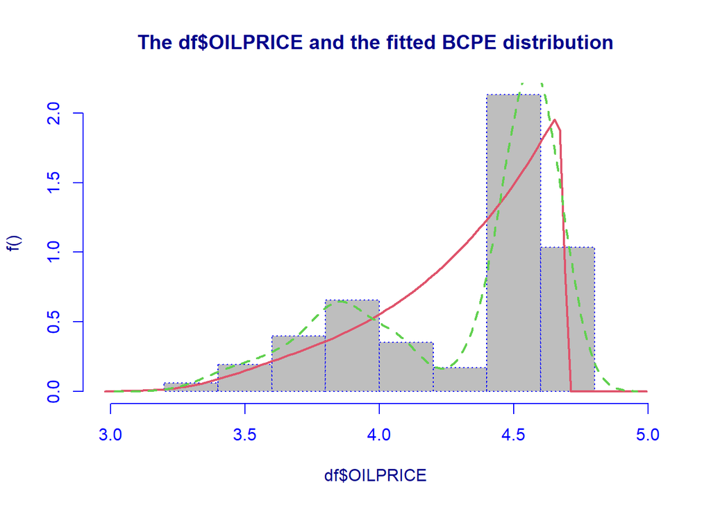

```
##
## Family:  c("BCPE", "Box-Cox Power Exponential")
## Fitting method: "nlminb"
##
## Call:  gamlssML(formula = df$OILPRICE, family = "BCPE")
##
## Mu Coefficients:
## [1]  4.374
## Sigma Coefficients:
## [1]  -2.877
## Nu Coefficients:
## [1]  9.382
## Tau Coefficients:
## [1]  3.339
##
##  Degrees of Freedom for the fit: 4 Residual Deg. of Freedom   996
## Global Deviance:     65.6076
##             AIC:     73.6076
##             SBC:     93.2387
```

```r
histDist(df$OILPRICE,
         family = BCPE ,
         density = T)
```

## MODEL TRAINING

NOW LET’S TRAIN OUR MODEL

THE TRAINING MODEL WILL BE PERFORMED IN 4 STEPS TO IDENTIFY IF THE PAST CONTRACTS LAGGED OR NOT LAGGED

WILL IMPACT IN THE MODEL PREDICTION, ALSO IT WILL BE COMPARED USING ADDITIVE TERMS: 1 - USING THE LAGGED VARIABLE ONLY, REMOVING THE PAST TRADED CONTRACTS NEGOTIATED (DF DATASET) 2 - USING ALL THE PAST CONTRACTS VARIABLES (OIL DATASET) 3 - APPLYING ADDITIVE TERMS IN DF DATASET 4 - APPLYING ADDITIVE TERMS IN OIL DATASET

Splitting data Train/Test: 70% trainset 30% testset.

```r
# DF dataset cut off the past traded Oil contracts and keep only the lagged variable
idx_DF = sample(dim(df)[1] , 0.70*dim(df)[1] , replace = F)
trainset_DF = df[idx_DF , ]
testset_DF = df[-idx_DF , ]

# OIL dataset keeps all the variables with no changes
idx_OIL = sample(dim(oil)[1] , 0.70*dim(oil)[1] , replace = F)
trainset_OIL = oil[idx_OIL , ]
testset_OIL = oil[-idx_OIL , ]
```

NO ADDITIVE TERMS

```r
show.link('BCPE')
```

```
## $mu
## c("inverse", "log", "identity", "own")
##
## $sigma
## c("inverse", "log", "identity", "own")
##
## $nu
## c("inverse", "log", "identity", "own")
##
## $tau
## c("logshiftto1", "log", "identity", "own")
```

```r
# Trainning the models: WITHOUT additive terms

mod_1 <- gamlss(OILPRICE ~ ., family = BCPE, data = trainset_DF, control = gamlss.control(n.cyc = 20))  # Model 1
```

```
## GAMLSS-RS iteration 1: Global Deviance = -2297.261
## GAMLSS-RS iteration 2: Global Deviance = -3167.61
## GAMLSS-RS iteration 3: Global Deviance = -3446.659
## GAMLSS-RS iteration 4: Global Deviance = -3456.684
## GAMLSS-RS iteration 5: Global Deviance = -3458.084
## GAMLSS-RS iteration 6: Global Deviance = -3459.008
## GAMLSS-RS iteration 7: Global Deviance = -3459.079
## GAMLSS-RS iteration 8: Global Deviance = -3459.463
## GAMLSS-RS iteration 9: Global Deviance = -3459.462
```

```r
mod_2 <- gamlss(OILPRICE ~ ., family = BCPE, data = trainset_OIL, control = gamlss.control(n.cyc = 20)) # model 2
```

```
## GAMLSS-RS iteration 1: Global Deviance = -2304.88
## GAMLSS-RS iteration 2: Global Deviance = -3143.735
## GAMLSS-RS iteration 3: Global Deviance = -3469.512
## GAMLSS-RS iteration 4: Global Deviance = -3507.495
## GAMLSS-RS iteration 5: Global Deviance = -3512.036
## GAMLSS-RS iteration 6: Global Deviance = -3512.883
## GAMLSS-RS iteration 7: Global Deviance = -3515.299
## GAMLSS-RS iteration 8: Global Deviance = -3515.431
## GAMLSS-RS iteration 9: Global Deviance = -3515.494
## GAMLSS-RS iteration 10: Global Deviance = -3515.287
## GAMLSS-RS iteration 11: Global Deviance = -3515.745
## GAMLSS-RS iteration 12: Global Deviance = -3516.001
## GAMLSS-RS iteration 13: Global Deviance = -3516.176
## GAMLSS-RS iteration 14: Global Deviance = -3515.434
## GAMLSS-RS iteration 15: Global Deviance = -3515.806
## GAMLSS-RS iteration 16: Global Deviance = -3515.125
## GAMLSS-RS iteration 17: Global Deviance = -3514.965
## GAMLSS-RS iteration 18: Global Deviance = -3515.118
## GAMLSS-RS iteration 19: Global Deviance = -3515.707
## GAMLSS-RS iteration 20: Global Deviance = -3515.96
```

```r
# Trainning the models: with additive terms

# model 3
mod_3 <-
  gamlss(
    OILPRICE ~ cs(BDIY_log, df = 2) + cs(SPX_log, df = 2) + cs(DX1_log, df = 2) + cs(GC1_log, df = 2) +
      cs(USCI_log, df = 2) + cs(GNR_log, df = 2) + cs(SHCOMP_log, df = 2) + cs(FTSE_log, df = 2) + cs(respLAG, df = 2) ,
    family = BCPE,
    data = trainset_DF
  )
```

```
## GAMLSS-RS iteration 1: Global Deviance = -2323.206
## GAMLSS-RS iteration 2: Global Deviance = -3152.95
## GAMLSS-RS iteration 3: Global Deviance = -3479.124
## GAMLSS-RS iteration 4: Global Deviance = -3487.837
## GAMLSS-RS iteration 5: Global Deviance = -3487.345
## GAMLSS-RS iteration 6: Global Deviance = -3485.157
## GAMLSS-RS iteration 7: Global Deviance = -3485.693
## GAMLSS-RS iteration 8: Global Deviance = -3486.816
## GAMLSS-RS iteration 9: Global Deviance = -3487.778
## GAMLSS-RS iteration 10: Global Deviance = -3489.38
## GAMLSS-RS iteration 11: Global Deviance = -3487.95
## GAMLSS-RS iteration 12: Global Deviance = -3487.87
## GAMLSS-RS iteration 13: Global Deviance = -3488.134
## GAMLSS-RS iteration 14: Global Deviance = -3490.78
## GAMLSS-RS iteration 15: Global Deviance = -3493.036
## GAMLSS-RS iteration 16: Global Deviance = -3492.362
## GAMLSS-RS iteration 17: Global Deviance = -3489.338
## GAMLSS-RS iteration 18: Global Deviance = -3491.084
## GAMLSS-RS iteration 19: Global Deviance = -3491.562
## GAMLSS-RS iteration 20: Global Deviance = -3489.267
```

```r
# model 4
mod_4 <-
  gamlss(
    OILPRICE ~ cs(CL2_log, df = 2) + cs(CL3_log, df = 2) + cs(CL4_log, df = 2) +
      cs(CL5_log, df = 2) + cs(CL6_log, df = 2) + cs(CL7_log, df = 2) +
      cs(CL8_log, df = 2) + cs(CL9_log, df = 2) + cs(CL10_log, df = 2) +
      cs(CL11_log, df = 2) + cs(CL12_log, df = 2) + cs(CL13_log, df = 2) +
      cs(CL14_log, df = 2) + cs(CL15_log, df = 2) +
      cs(BDIY_log, df = 2) + cs(SPX_log, df = 2) + cs(DX1_log, df = 2) + cs(GC1_log, df = 2) +
      cs(USCI_log, df = 2) + cs(GNR_log, df = 2) + cs(SHCOMP_log, df = 2) + cs(FTSE_log, df = 2) + cs(respLAG, df = 2) ,
    family = BCPE,
    data = trainset_OIL
  )
```

```
## GAMLSS-RS iteration 1: Global Deviance = -2336.039
## GAMLSS-RS iteration 2: Global Deviance = -3126.541
## GAMLSS-RS iteration 3: Global Deviance = -3482.323
## GAMLSS-RS iteration 4: Global Deviance = -3531.478
## GAMLSS-RS iteration 5: Global Deviance = -3534.229
## GAMLSS-RS iteration 6: Global Deviance = -3524.374
## GAMLSS-RS iteration 7: Global Deviance = -3519.523
## GAMLSS-RS iteration 8: Global Deviance = -3530.028
## GAMLSS-RS iteration 9: Global Deviance = -3526.339
## GAMLSS-RS iteration 10: Global Deviance = -3525.009
## GAMLSS-RS iteration 11: Global Deviance = -3530.89
## GAMLSS-RS iteration 12: Global Deviance = -3530.09
## GAMLSS-RS iteration 13: Global Deviance = -3534.797
## GAMLSS-RS iteration 14: Global Deviance = -3530.412
## GAMLSS-RS iteration 15: Global Deviance = -3531.056
## GAMLSS-RS iteration 16: Global Deviance = -3530.52
## GAMLSS-RS iteration 17: Global Deviance = -3530.779
## GAMLSS-RS iteration 18: Global Deviance = -3530.356
## GAMLSS-RS iteration 19: Global Deviance = -3529.638
## GAMLSS-RS iteration 20: Global Deviance = -3529.237
```

```r
# 0 > DF PARAMETER RANGE =< 5.
find.hyper(mod_1,parameters=c(0.01,5))
```

```
## par 0.01 5 crit= -3431.462 with pen= 2
## par 0.11 5 crit= -3431.462 with pen= 2
## par -0.09 5 crit= -3431.462 with pen= 2
## par 0.01 5.1 crit= -3431.462 with pen= 2
## par 0.01 4.9 crit= -3431.462 with pen= 2
```

```
## $par
## [1] 0.01 5.00
##
## $value
## [1] -3431.462
##
## $counts
## function gradient
##        1        1
##
## $convergence
## [1] 0
##
## $message
## [1] "CONVERGENCE: NORM OF PROJECTED GRADIENT <= PGTOL"
```

```r
find.hyper(mod_2,parameters=c(0.01,5))
```

```
## par 0.01 5 crit= -3459.96 with pen= 2
## par 0.11 5 crit= -3459.96 with pen= 2
## par -0.09 5 crit= -3459.96 with pen= 2
## par 0.01 5.1 crit= -3459.96 with pen= 2
## par 0.01 4.9 crit= -3459.96 with pen= 2
```

```
## $par
## [1] 0.01 5.00
##
## $value
## [1] -3459.96
##
## $counts
## function gradient
##        1        1
##
## $convergence
## [1] 0
##
## $message
## [1] "CONVERGENCE: NORM OF PROJECTED GRADIENT <= PGTOL"
```

```r
find.hyper(mod_3,parameters=c(0.01,5))
```

```
## par 0.01 5 crit= -3427.264 with pen= 2
## par 0.11 5 crit= -3427.264 with pen= 2
## par -0.09 5 crit= -3427.264 with pen= 2
## par 0.01 5.1 crit= -3427.264 with pen= 2
## par 0.01 4.9 crit= -3427.264 with pen= 2
```

```
## $par
## [1] 0.01 5.00
##
## $value
## [1] -3427.264
##
## $counts
## function gradient
##        1        1
##
## $convergence
## [1] 0
##
## $message
## [1] "CONVERGENCE: NORM OF PROJECTED GRADIENT <= PGTOL"
```

```r
find.hyper(mod_4,parameters=c(0.01,5))
```

```
## par 0.01 5 crit= -3383.245 with pen= 2
## par 0.11 5 crit= -3383.245 with pen= 2
## par -0.09 5 crit= -3383.245 with pen= 2
## par 0.01 5.1 crit= -3383.245 with pen= 2
## par 0.01 4.9 crit= -3383.245 with pen= 2
```

```
## $par
## [1] 0.01 5.00
##
## $value
## [1] -3383.245
##
## $counts
## function gradient
##        1        1
##
## $convergence
## [1] 0
##
## $message
## [1] "CONVERGENCE: NORM OF PROJECTED GRADIENT <= PGTOL"
```

```r
# Models estimators
summary(mod_1)
```

```
## Family:  c("BCPE", "Box-Cox Power Exponential")
##
## Call:  gamlss(formula = OILPRICE ~ ., family = BCPE, data = trainset_DF,
##     control = gamlss.control(n.cyc = 20))
##
## Fitting method: RS()
##
## ------------------------------------------------------------------
## Mu link function:  identity
## Mu Coefficients:
##              Estimate Std. Error t value Pr(>|t|)
## (Intercept)  0.909406   0.204324   4.451 9.98e-06 ***
## BDIY_log    -0.006375   0.001591  -4.008 6.80e-05 ***
## SPX_log     -0.082076   0.010757  -7.630 7.85e-14 ***
## DX1_log     -0.053284   0.022880  -2.329  0.02016 *
## GC1_log     -0.065378   0.010921  -5.986 3.45e-09 ***
## HO1_log     -0.003580   0.010547  -0.339  0.73436
## USCI_log     0.013876   0.016950   0.819  0.41328
## GNR_log      0.037910   0.015170   2.499  0.01269 *
## SHCOMP_log  -0.008110   0.004547  -1.784  0.07493 .
## FTSE_log     0.049862   0.015468   3.224  0.00133 **
## respLAG      0.973506   0.007240 134.455  < 2e-16 ***
## ---
## Signif. codes:  0 '***' 0.001 '**' 0.01 '*' 0.05 '.' 0.1 ' ' 1
##
## ------------------------------------------------------------------
## Sigma link function:  log
## Sigma Coefficients:
##             Estimate Std. Error t value Pr(>|t|)
## (Intercept)  -5.1710     0.0438  -118.1   <2e-16 ***
## ---
## Signif. codes:  0 '***' 0.001 '**' 0.01 '*' 0.05 '.' 0.1 ' ' 1
##
## ------------------------------------------------------------------
## Nu link function:  identity
## Nu Coefficients:
##             Estimate Std. Error t value Pr(>|t|)
## (Intercept)   -9.186      7.402  -1.241    0.215
##
## ------------------------------------------------------------------
## Tau link function:  log
## Tau Coefficients:
##             Estimate Std. Error t value Pr(>|t|)
## (Intercept) -0.29716    0.05472   -5.43 7.77e-08 ***
## ---
## Signif. codes:  0 '***' 0.001 '**' 0.01 '*' 0.05 '.' 0.1 ' ' 1
##
## ------------------------------------------------------------------
## No. of observations in the fit:  700
## Degrees of Freedom for the fit:  14
##       Residual Deg. of Freedom:  686
##                       at cycle:  9
##
## Global Deviance:     -3459.462
##             AIC:     -3431.462
##             SBC:     -3367.747
```

```r
summary(mod_2)
```

```
## Family:  c("BCPE", "Box-Cox Power Exponential")
##
## Call:  gamlss(formula = OILPRICE ~ ., family = BCPE, data = trainset_OIL,
##     control = gamlss.control(n.cyc = 20))
##
## Fitting method: RS()
##
## ------------------------------------------------------------------
## Mu link function:  identity
## Mu Coefficients:
##               Estimate Std. Error t value Pr(>|t|)
## (Intercept)   0.474285   0.112736   4.207 2.94e-05 ***
## CL2_log      -2.356988   0.194474 -12.120  < 2e-16 ***
## CL3_log       8.196310   0.548435  14.945  < 2e-16 ***
## CL4_log     -10.303394   0.458938 -22.451  < 2e-16 ***
## CL5_log       3.173456   0.483931   6.558 1.09e-10 ***
## CL6_log       4.425470   1.108848   3.991 7.30e-05 ***
## CL7_log      -8.900924   1.017633  -8.747  < 2e-16 ***
## CL8_log      10.307533   0.892911  11.544  < 2e-16 ***
## CL9_log      -4.403727   0.576660  -7.637 7.65e-14 ***
## CL10_log     -0.144154   0.010050 -14.344  < 2e-16 ***
## CL11_log     -1.996623   0.519801  -3.841 0.000134 ***
## CL12_log      1.807129   0.827871   2.183 0.029390 *
## CL13_log      1.245384   0.917549   1.357 0.175142
## CL14_log     -0.811726   0.682270  -1.190 0.234565
## CL15_log     -0.329317   0.316781  -1.040 0.298912
## BDIY_log     -0.004007   0.000858  -4.670 3.64e-06 ***
## SPX_log      -0.050320   0.007162  -7.026 5.20e-12 ***
## DX1_log      -0.070914   0.017358  -4.085 4.93e-05 ***
## GC1_log      -0.029287   0.005822  -5.030 6.29e-07 ***
## HO1_log       0.011983   0.005870   2.041 0.041611 *
## USCI_log      0.015409   0.009751   1.580 0.114517
## GNR_log      -0.020977   0.012749  -1.645 0.100363
## SHCOMP_log   -0.012944   0.002948  -4.391 1.31e-05 ***
## FTSE_log      0.077490   0.012272   6.314 4.92e-10 ***
## respLAG       1.064825   0.031834  33.449  < 2e-16 ***
## ---
## Signif. codes:  0 '***' 0.001 '**' 0.01 '*' 0.05 '.' 0.1 ' ' 1
##
## ------------------------------------------------------------------
```

[output cut: 15 more lines]

```
## Tau Coefficients:
##             Estimate Std. Error t value Pr(>|t|)
## (Intercept) -0.46735    0.04998  -9.351   <2e-16 ***
## ---
## Signif. codes:  0 '***' 0.001 '**' 0.01 '*' 0.05 '.' 0.1 ' ' 1
##
## ------------------------------------------------------------------
## No. of observations in the fit:  700
## Degrees of Freedom for the fit:  28
##       Residual Deg. of Freedom:  672
##                       at cycle:  20
##
## Global Deviance:     -3515.96
##             AIC:     -3459.96
##             SBC:     -3332.53
```

```r
summary(mod_3)
```

```
## Family:  c("BCPE", "Box-Cox Power Exponential")
##
## Call:  gamlss(formula = OILPRICE ~ cs(BDIY_log, df = 2) + cs(SPX_log,
##     df = 2) + cs(DX1_log, df = 2) + cs(GC1_log, df = 2) + cs(USCI_log,
##     df = 2) + cs(GNR_log, df = 2) + cs(SHCOMP_log, df = 2) +
##     cs(FTSE_log, df = 2) + cs(respLAG, df = 2), family = BCPE,
##     data = trainset_DF)
##
## Fitting method: RS()
##
## ------------------------------------------------------------------
## Mu link function:  identity
## Mu Coefficients:
##                         Estimate Std. Error t value Pr(>|t|)
## (Intercept)             0.499577   0.142242   3.512 0.000474 ***
## cs(BDIY_log, df = 2)   -0.003513   0.001087  -3.231 0.001295 **
## cs(SPX_log, df = 2)    -0.058578   0.008181  -7.160 2.12e-12 ***
## cs(DX1_log, df = 2)    -0.014900   0.017573  -0.848 0.396799
## cs(GC1_log, df = 2)    -0.026091   0.008159  -3.198 0.001449 **
## cs(USCI_log, df = 2)   -0.005587   0.012227  -0.457 0.647848
## cs(GNR_log, df = 2)     0.018064   0.010545   1.713 0.087166 .
## cs(SHCOMP_log, df = 2) -0.023246   0.003455  -6.727 3.70e-11 ***
## cs(FTSE_log, df = 2)    0.050457   0.012169   4.146 3.81e-05 ***
## cs(respLAG, df = 2)     0.979023   0.003771 259.624  < 2e-16 ***
## ---
## Signif. codes:  0 '***' 0.001 '**' 0.01 '*' 0.05 '.' 0.1 ' ' 1
##
## ------------------------------------------------------------------
## Sigma link function:  log
## Sigma Coefficients:
##             Estimate Std. Error t value Pr(>|t|)
## (Intercept) -5.17111    0.04483  -115.4   <2e-16 ***
## ---
## Signif. codes:  0 '***' 0.001 '**' 0.01 '*' 0.05 '.' 0.1 ' ' 1
##
## ------------------------------------------------------------------
## Nu link function:  identity
## Nu Coefficients:
##             Estimate Std. Error t value Pr(>|t|)
## (Intercept)   -5.769      7.522  -0.767    0.443
##
## ------------------------------------------------------------------
## Tau link function:  log
## Tau Coefficients:
##             Estimate Std. Error t value Pr(>|t|)
## (Intercept) -0.34156    0.05346  -6.389 3.04e-10 ***
## ---
## Signif. codes:  0 '***' 0.001 '**' 0.01 '*' 0.05 '.' 0.1 ' ' 1
##
## ------------------------------------------------------------------
## NOTE: Additive smoothing terms exist in the formulas:
##  i) Std. Error for smoothers are for the linear effect only.
## ii) Std. Error for the linear terms may not be reliable.
## ------------------------------------------------------------------
## No. of observations in the fit:  700
## Degrees of Freedom for the fit:  31.00179
##       Residual Deg. of Freedom:  668.9982
##                       at cycle:  20
##
## Global Deviance:     -3489.267
##             AIC:     -3427.264
##             SBC:     -3286.172
```